# Figuren-overzicht — *De regressieve ruggengraat*

Contactblad dat meegroeit: het toont wat er nú in `02_figuren/` staat.

Werkblad voor onszelf — geen publieksbladzijde. Alle gebouwde figuren náást elkaar, per hoofdstuk, zodat je in één oogopslag de dekking en de consistentie (zoals de as-stijl) ziet. Regenereert zichzelf uit de map; draai `quarto render figuren_overzicht.qmd` na een figuren-ronde en hij klopt weer.

Tekst-register (wat is er / wat mist / wie hoort waar): `FIGUREN_REGISTER.md`.

## H1

`h1_streepjes.png`

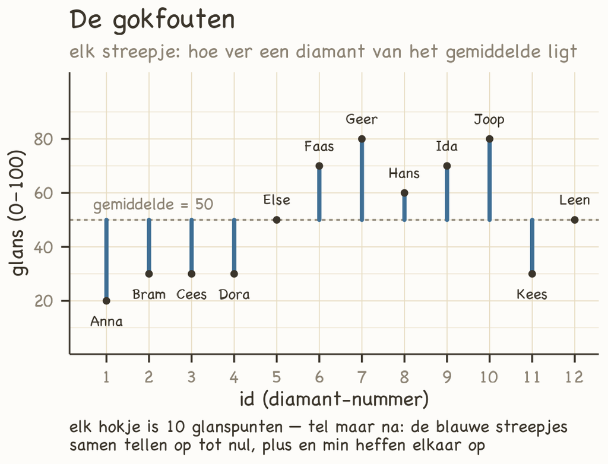

`h1_vierkantjes.png`

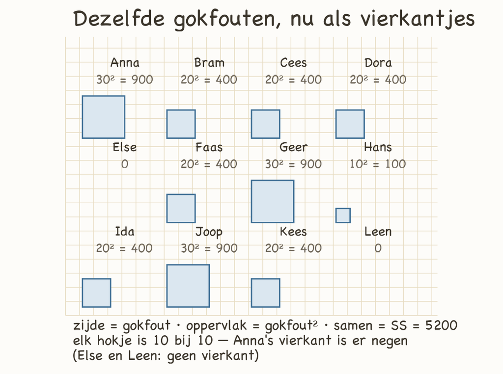

## H2

`h2_boxplot.png`

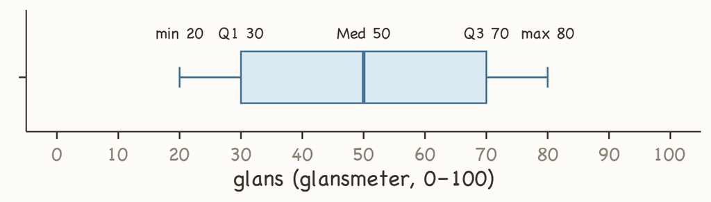

`h2_rij.png`

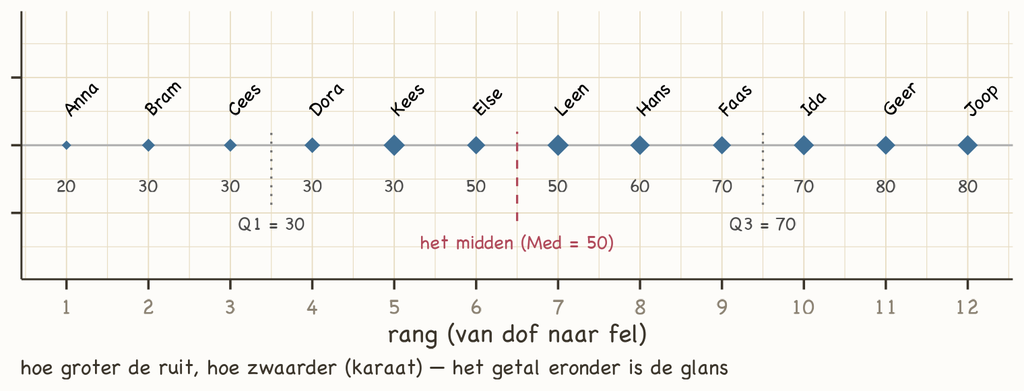

`h2_stapels.png`

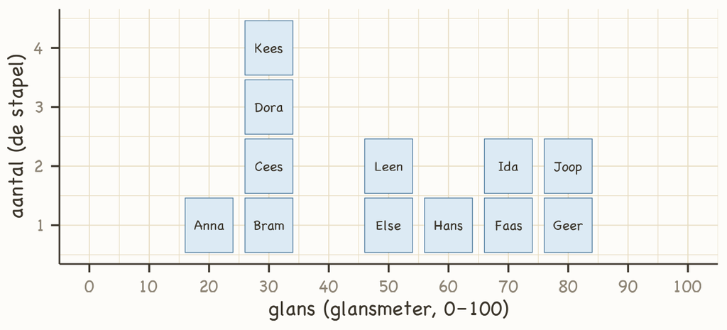

`h2_vier_straten.png`

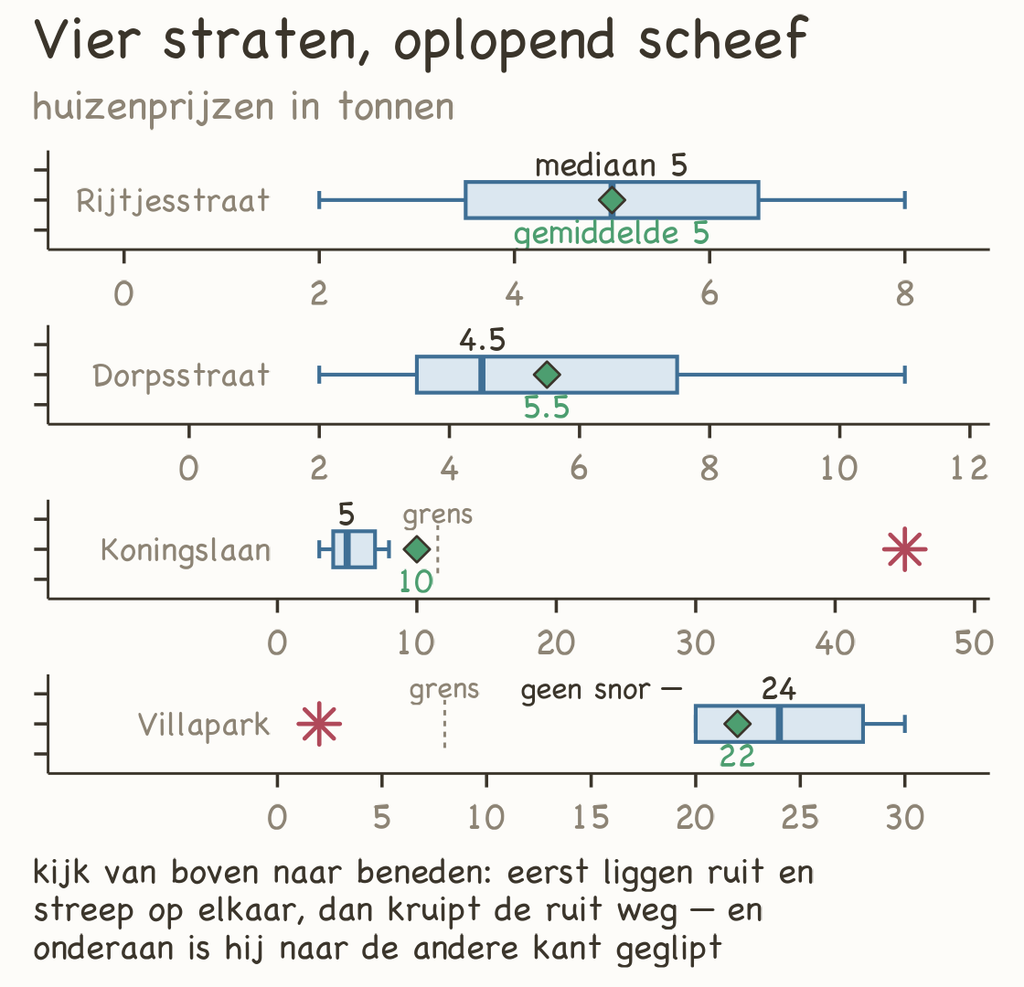

## H3

`h3_bordjesmuur_reeks.png`

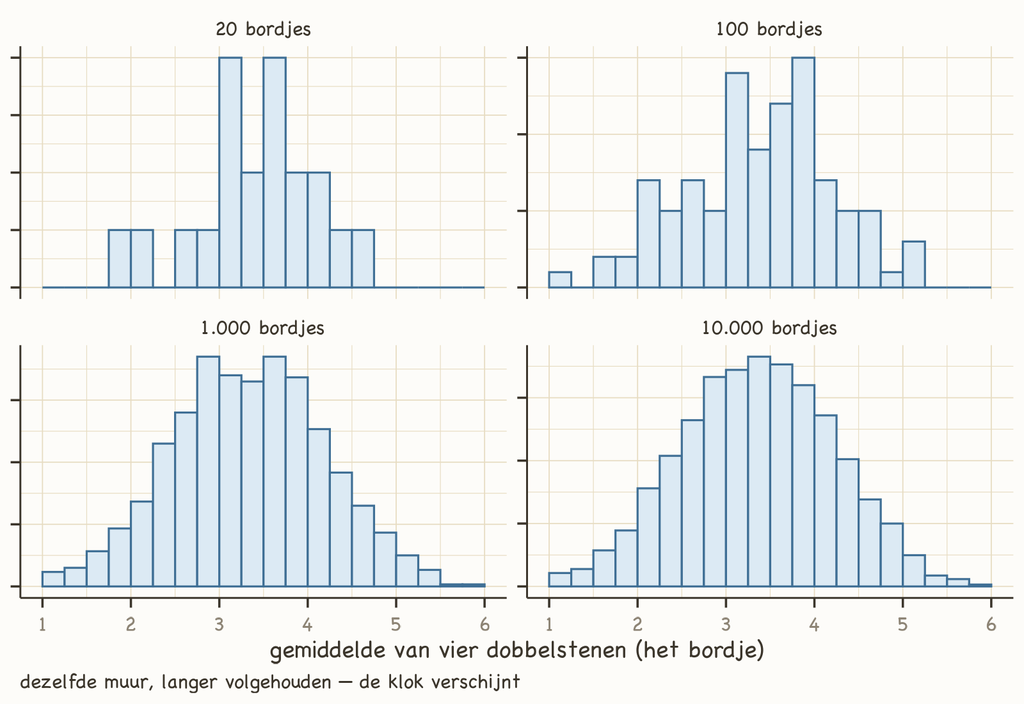

`h3_drie_verdelingen.png`

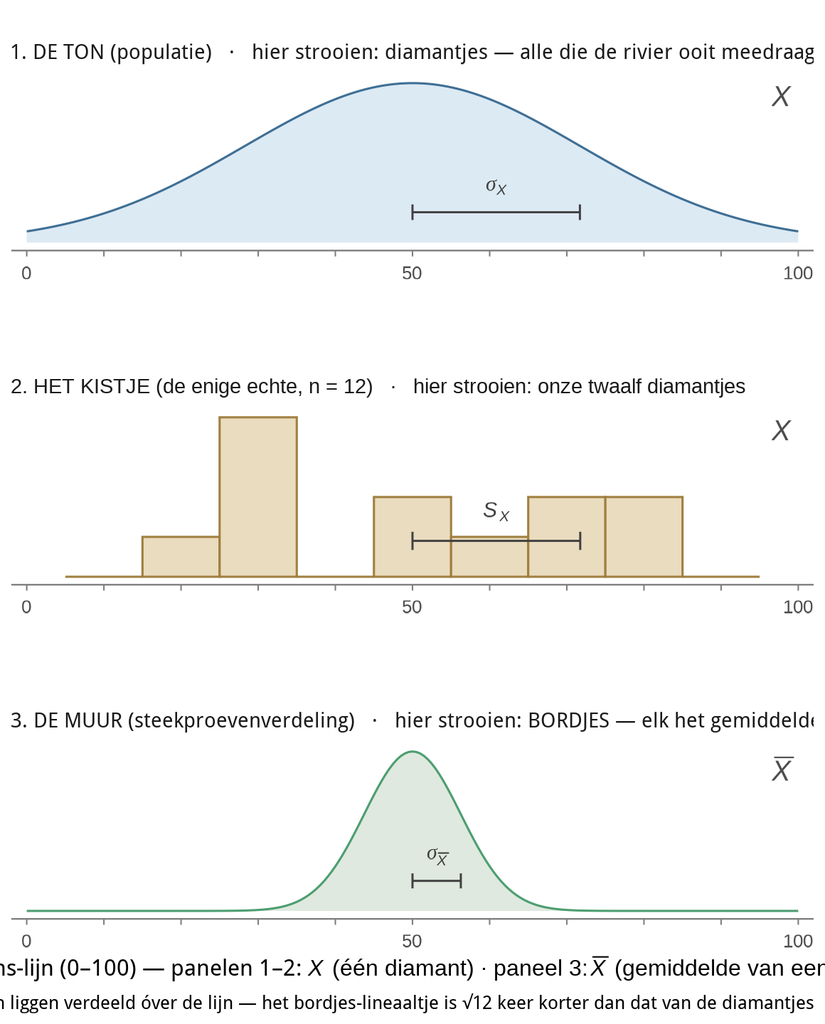

`h3_turf.png`

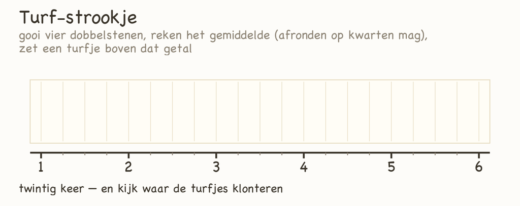

## H4

`h4_armen_poppetjes.png`

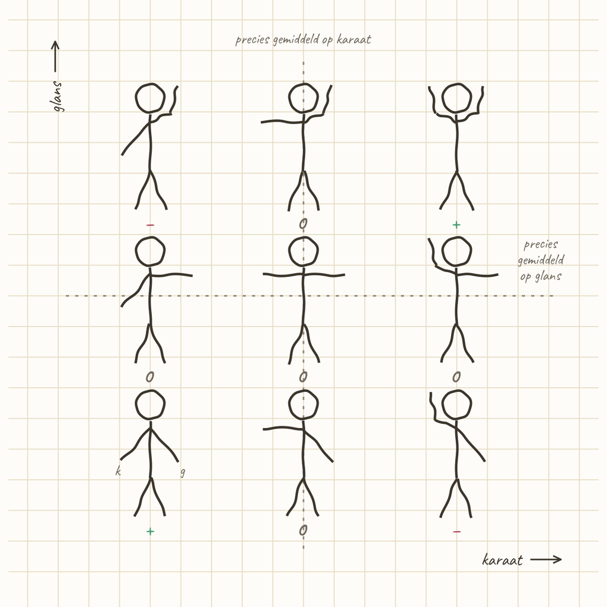

`h4_centroide.png`

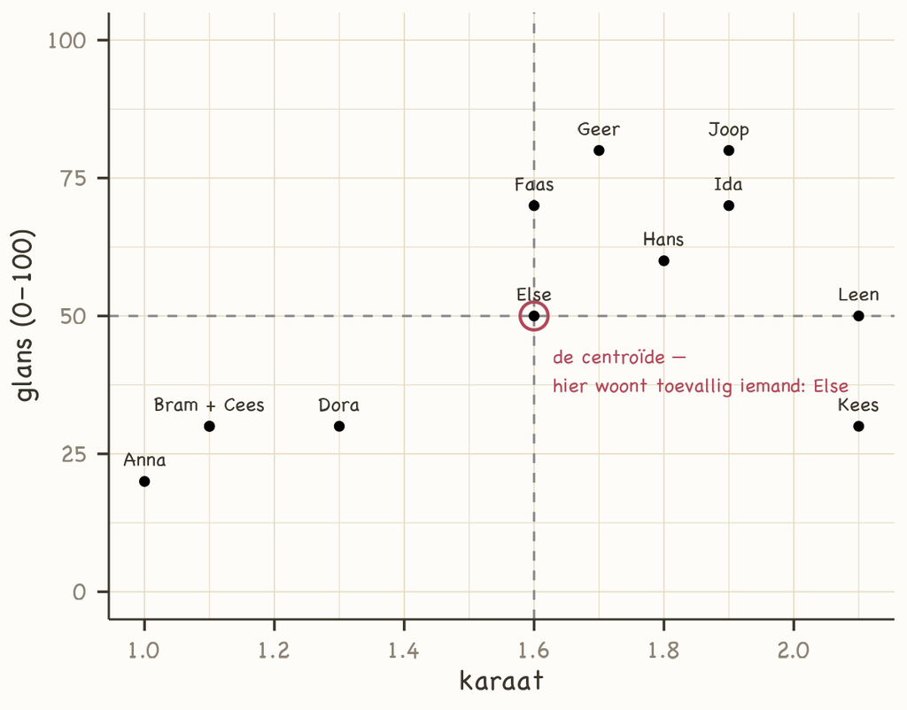

`h4_lijn.png`

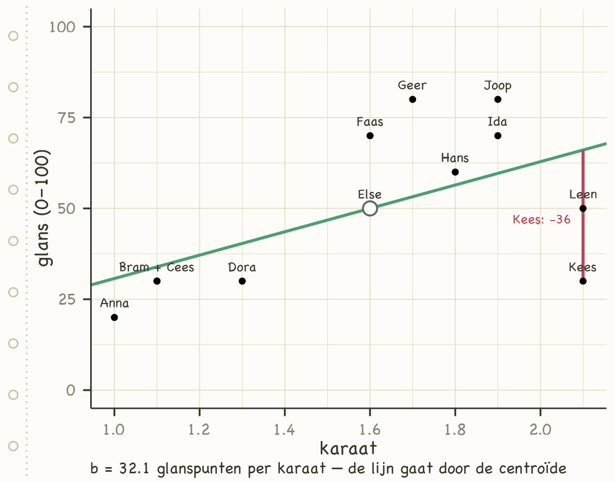

`h4_rechthoekjes.png`

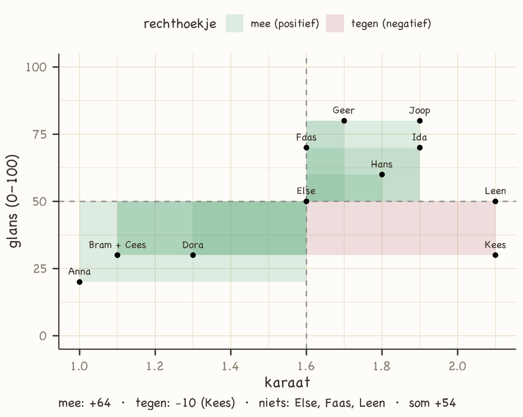

## H5

`h5_trap.png`

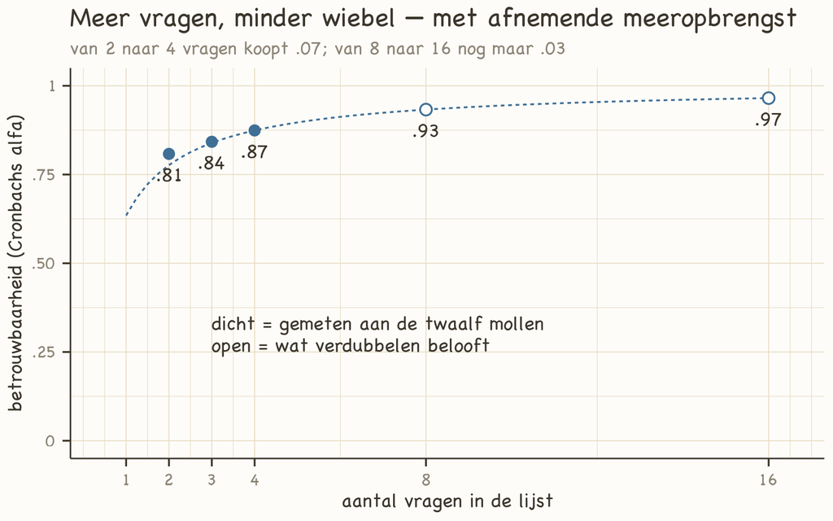

## H6

`h6_muur_boot_gemiddelde.png`

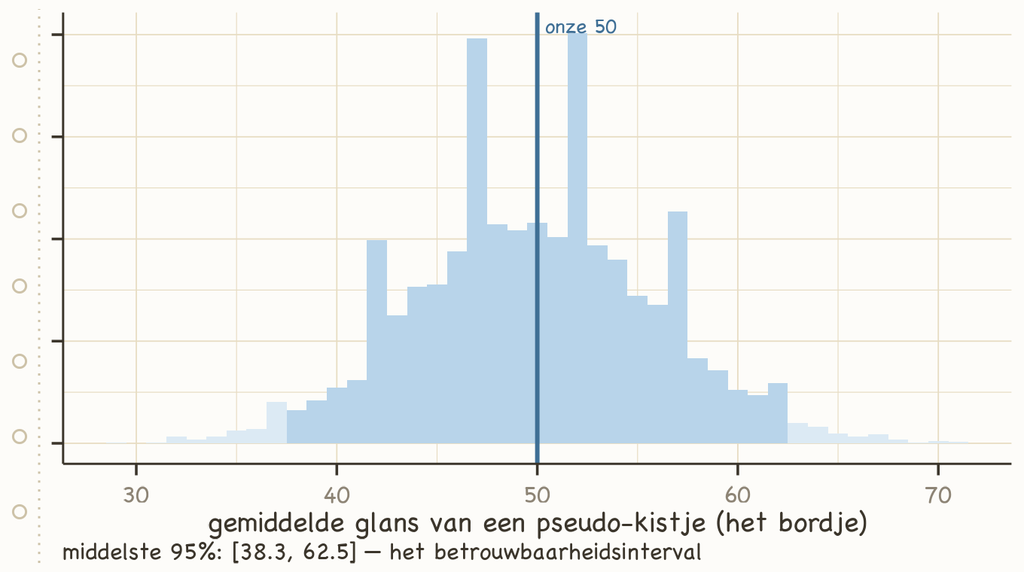

`h6_muur_boot_r.png`

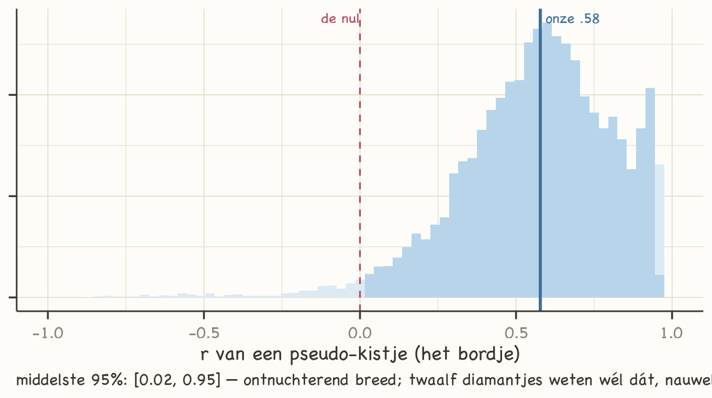

`h6_muur_permutatie.png`

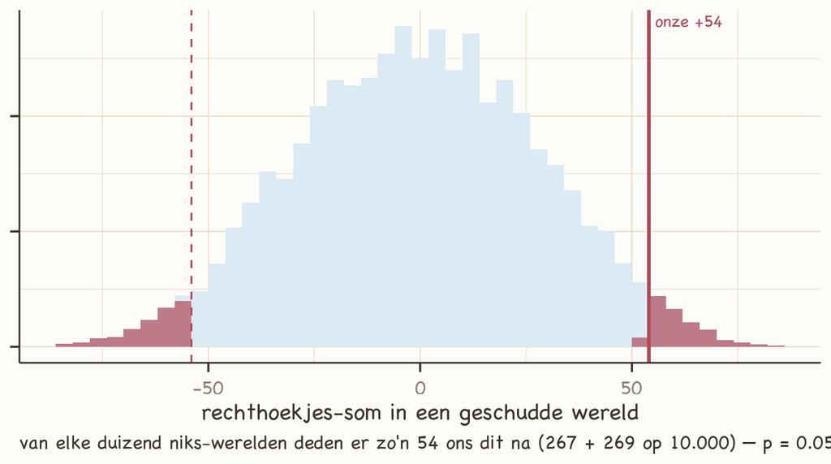

`h6_twee_muren.png`

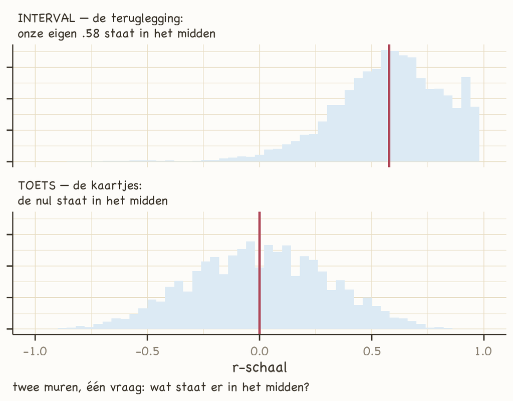

## H7

`h7_beslismatrix.png`

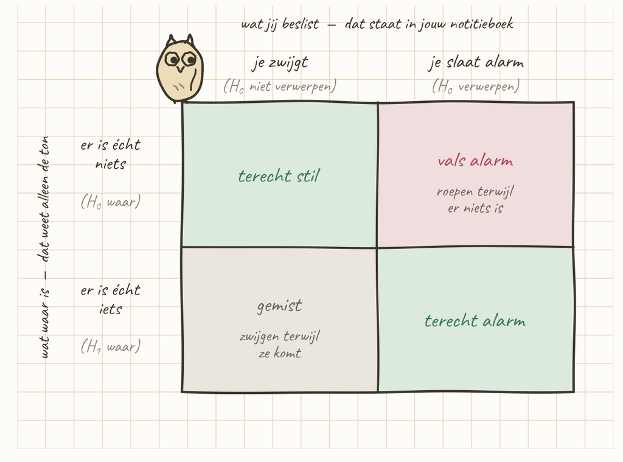

`h7_twee_klokken.png`

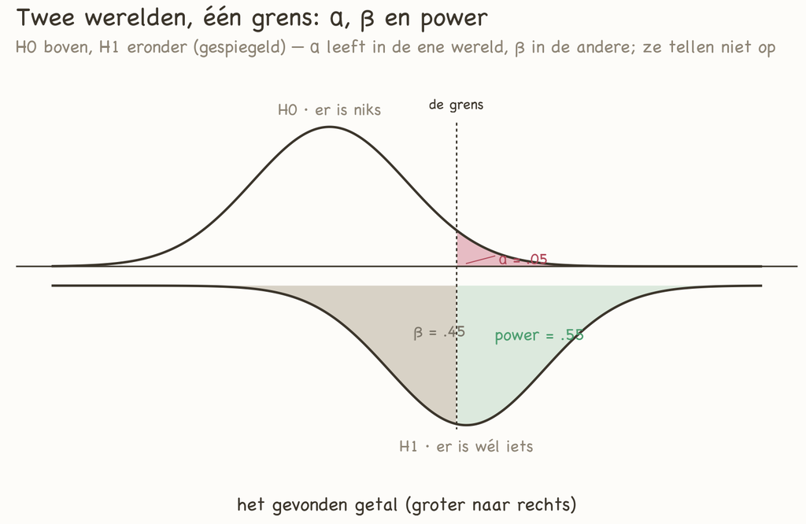

`h7_valse_alarmen.png`

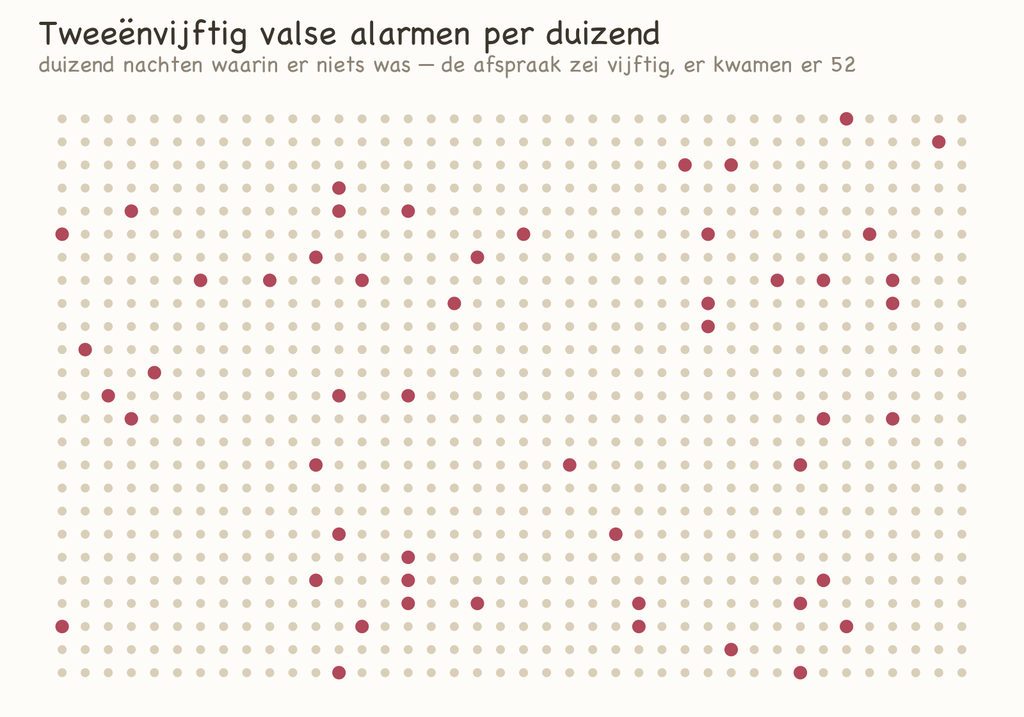

`h7_vangkans.png`

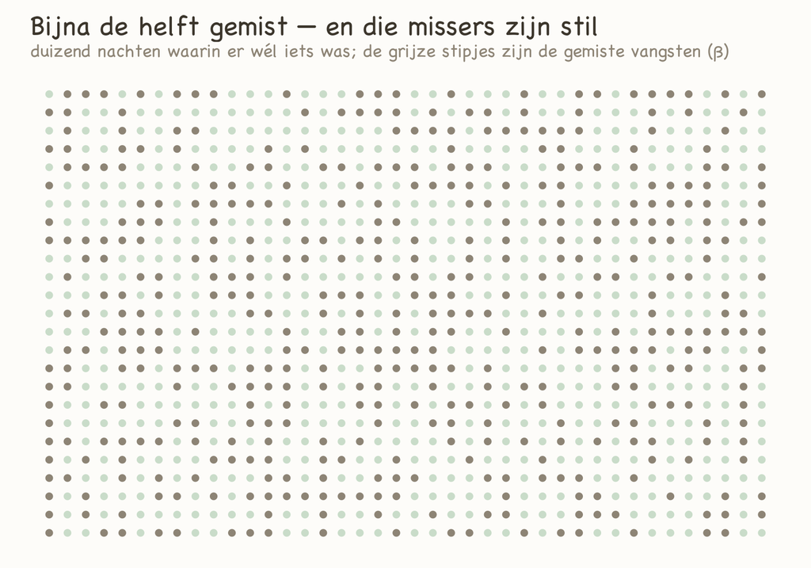

## H8

`h8_oppervlaktes.png`

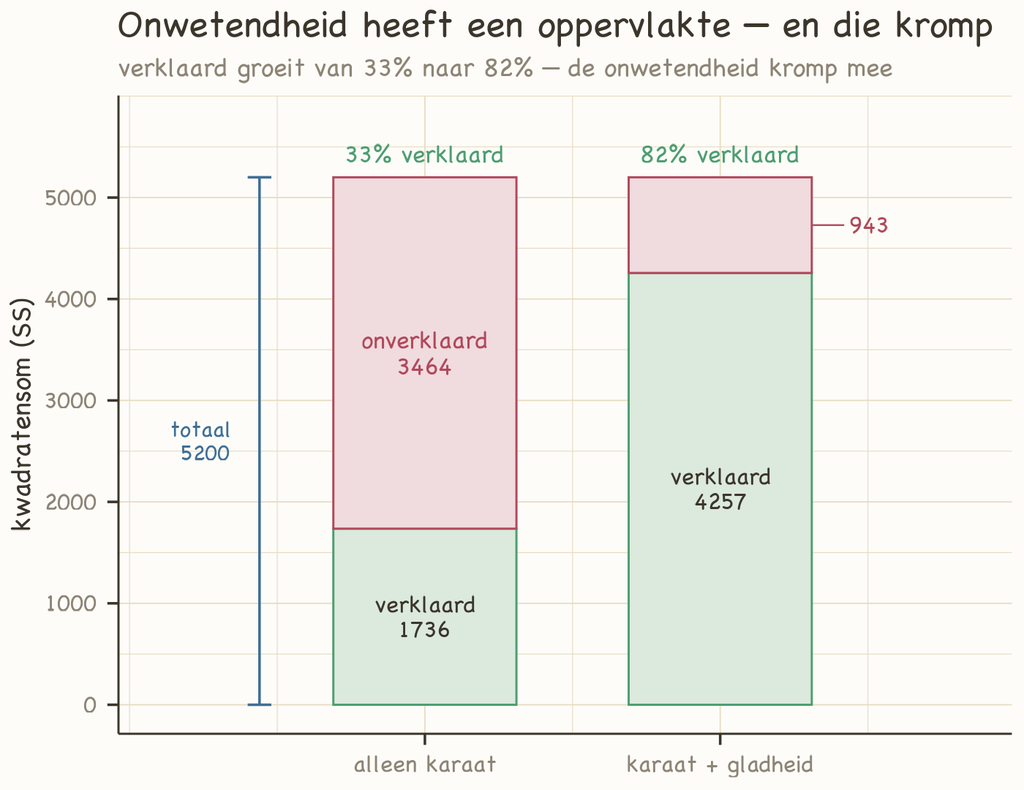

`h8_pijltjes.png`

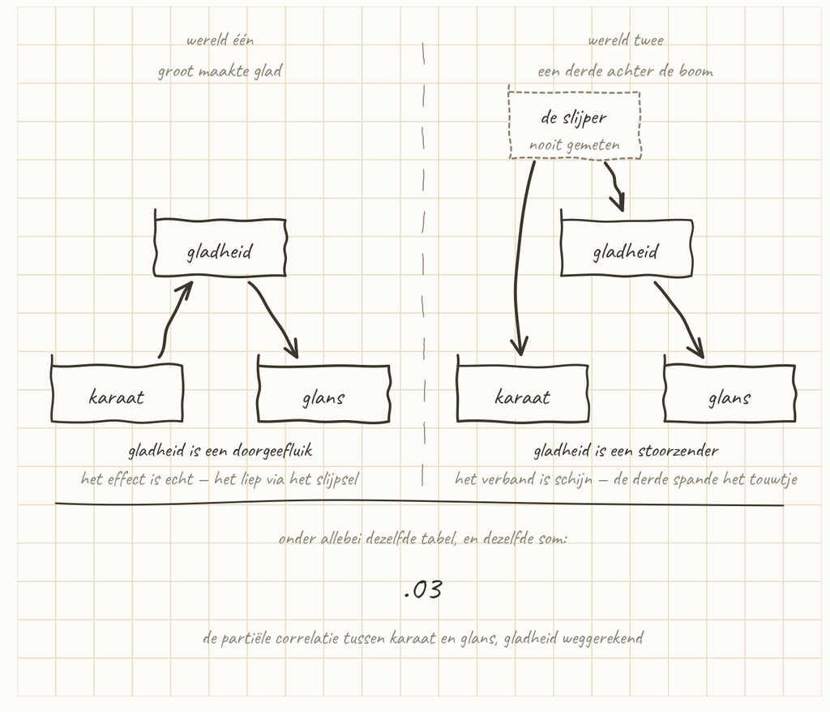

`h8_venn.png`

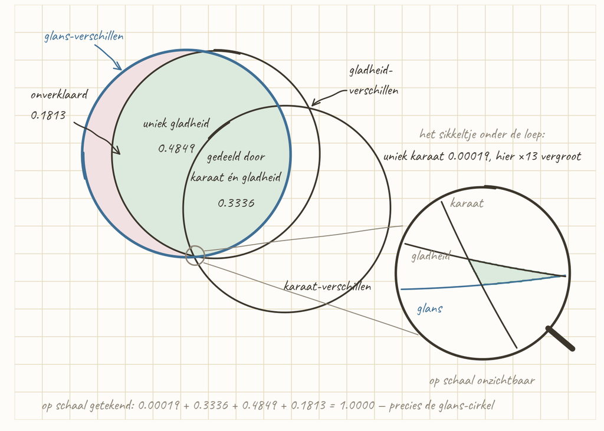

`h8_wegrekenen_tweeluik.png`

[figure not shown]

## H9

`h9_error_peuzel.png`

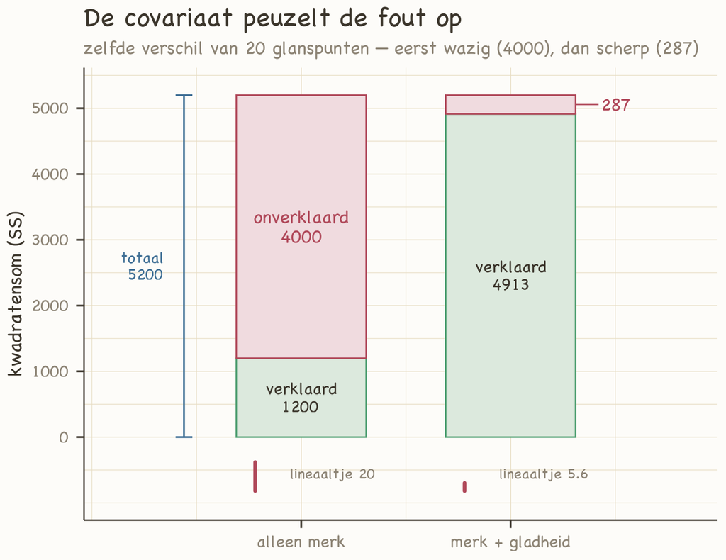

`h9_evenwijdig.png`

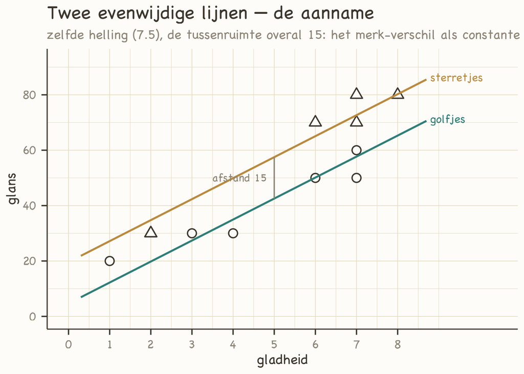

`h9_twee_stapels.png`

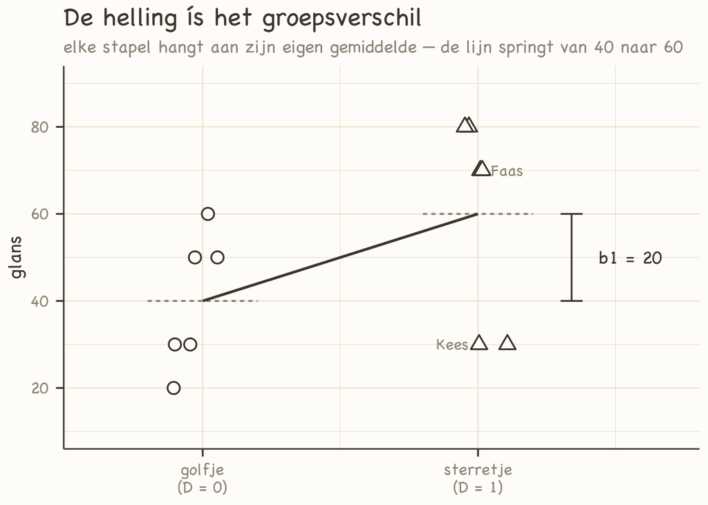

## H10

`h10_ladder.png`

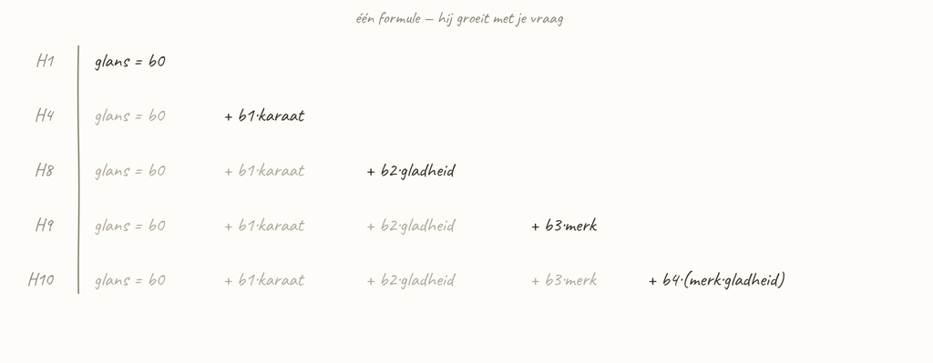

`h10_schaar.png`

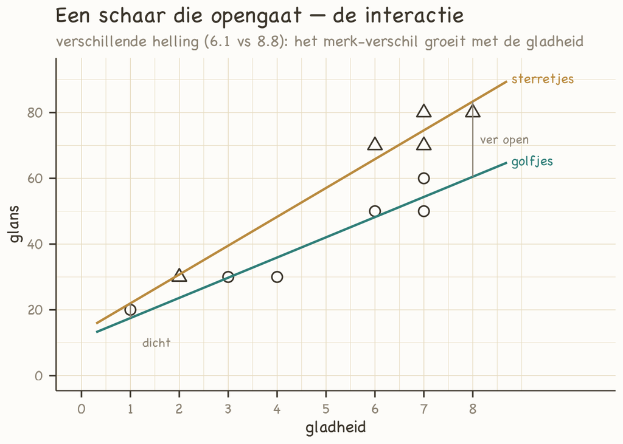